# Coursera:Project of Machine Learning

Chen

2020/5/2

# Background

Using devices such as Jawbone Up , Nike FuelBand , and Fitbit it is now possible to collect a large amount of data about personal activity relatively inexpensively. These type of devices are part of the quantified self movement – a group of enthusiasts who take measurements about themselves regularly to improve their health, to find patterns in their behavior, or because they are tech geeks. One thing that people regularly do is quantify how much of a particular activity they do, but they rarely quantify how well they do it . In this project, your goal will be to use data from accelerometers on the belt, forearm, arm, and dumbell of 6 participants. They were asked to perform barbell lifts correctly and incorrectly in 5 different ways. More information is available from the website here: [see the section on the Weight Lifting Exercise Dataset](http://groupware.les.inf.puc-rio.br/har%3E).

# Data

The training data for this project are available [here](https://d396qusza40orc.cloudfront.net/predmachlearn/pml-training.csv).

The test data are available [here](https://d396qusza40orc.cloudfront.net/predmachlearn/pml-testing.csv).

The data for this project come from this [source](http://groupware.les.inf.puc-rio.br/har). If you use the document you create for this class for any purpose please cite them as they have been very generous in allowing their data to be used for this kind of assignment.

# Open R Packages

In this project we need Packages for Machine Leanring, plot, etc. What we used as followed:

```r
library(lattice); library(ggplot2); library(caret);  library(data.table);library(rattle)
```

# DownLoading Databases

```r
url1 <- "https://d396qusza40orc.cloudfront.net/predmachlearn/pml-testing.csv"
download.file(url1,destfile = "./testing.csv",method="wininet")
url2 <- "https://d396qusza40orc.cloudfront.net/predmachlearn/pml-training.csv"
download.file(url2,destfile = "./training.csv",method="wininet")
rm(url1);rm(url2)
```

# Read Data

We have already down load fields, let’s just read it.

```r
Dtraining<-read.table("./training.csv",sep=",",header=TRUE)
Dtest<-read.table("./testing.csv",sep=",",header=TRUE)
```

# Cleaning the data

1. Removing NA datas.

```r
cond <- colSums(is.na(Dtraining)) == 0
trainingset<-Dtraining[,cond]
testset<-Dtest[,cond]
rm(cond)
```

2. Removing unrelative variables.

```r
regex <- grepl("^X|timestamp|user_name", names(trainingset))
trainingset <- trainingset[, !regex]
testset <- testset[, !regex]
rm(regex)
```

3. Removing Near Zero Variables.

```r
NZV <- nearZeroVar(trainingset, saveMetrics = TRUE)
trainingset <- trainingset[, !NZV$nzv]
testset <- testset[, !NZV$nzv]
rm(NZV)
```

# Partitioning Traning Set for Cross Validation

we split the cleaned training set into a pure training data set (75%) and a validation data set (25%). We will use the validation data set to conduct cross validation in future steps.

```r
traintrainset <- createDataPartition(y=trainingset$classe, p=0.75, list=FALSE)
TrainTrainingSet <- trainingset[traintrainset, ]
ValidationTrainingSet <- trainingset[-traintrainset, ]
```

Let’s see the histgram of thoese two sets.

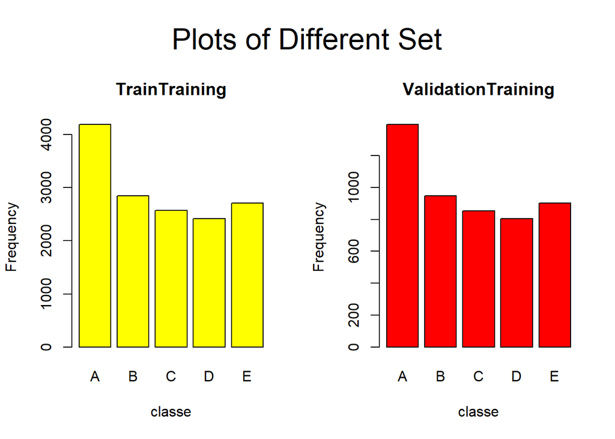

```r
par(mfrow=c(1,2),oma = c(0, 0, 3, 0))
plot(TrainTrainingSet$classe, col="yellow", xlab="classe", ylab="Frequency")
title(main="TrainTraining")
plot(ValidationTrainingSet$classe, col="red", xlab="classe", ylab="Frequency")
title(main="ValidationTraining")
mtext("Plots of Different Set", side = 3, line = 0, outer = T,cex=2)
```

The Dataset now consists of 54 variables with the observations divided as following:  
1. Training Data: 14718 observations.  
2. Validation Data: 4904 observations.  
3. Testing Data: 20 observations.

Based on the graph above, we can see that each level frequency is within the same order of magnitude of each other. Level A is the most frequent while level D is the least frequent.